# Final_Project_Manajit_Gogate_Problem_2.1

```python
import numpy as np
import pandas as pd
from scipy.optimize import minimize, curve_fit
import numpy as np
import pandas as pd
from scipy.optimize import minimize, curve_fit
import numdifftools as nd
from statsmodels.tsa.stattools import adfuller
import math
import seaborn as sns
import matplotlib.pyplot as plt
from matplotlib import style
style.use('default')
```

## Implementation of 2-Factor Vasicek model:

Intitially I define all the parameters needed. Please see scan document for derivation part.

```python
def A(p, c, tau):
    mu1 = p[0]
    k1 = p[1]
    mu2 = p[2]
    k2 = p[3]
    s1 = c[0]
    s2 = c[1]
    cor = c[2]

    Term1 = ((mu1/k1) +(mu2/k2) - (s1**2/(2*k1)) - (s2**2/(2*k2)) - (s1*s2*cor/(k1*k2))) * tau
    Term2 = ((s1**2/k1**3) + (s1*s2*cor/(2*(k1**2)*k2)) - (mu1/k1**2)) * (1-np.exp(-k1*tau))
    Term3 = ((s2**2/k2**3) + (s1*s2*cor/(2*(k2**2)*k2)) - (mu2/k2**2)) * (1-np.exp(-k2*tau))
    Term4 = - (s1**2/(4*k1**3)) * (1-np.exp(-2*k1*tau))
    Term5 = - (s2**2/(4*k2**3)) * (1-np.exp(-2*k2*tau))
    Term6 = - ((s1*s2*cor/(k1*k2*(k1+k2)))) * ((1-np.exp(-(k1 + k2)*tau)))
    A = Term1 + Term2 + Term3 + Term4 + Term5 + Term6

    return A
```

```python
def B1(p, tau):

    mu1 = p[0]
    k1 = p[1]

    B1 = (1/k1) * (1 - np.exp(-k1*tau))
    return B1
```

```python
def B2(p, tau):

    mu2 = p[2]
    k2 = p[3]

    B2 = (1/k2) * (1 - np.exp(-k2*tau))
    return B2
```

```python
def expctx1(p, tau):

    mu1 = p[0]
    k1 = p[1]

    e1 = np.exp(-k1*tau) + ((mu1/k1)*(1-np.exp(-k1*tau)))

    return e1
```

```python
def expctx2(p, tau):

    mu2 = p[2]
    k2 = p[3]

    e2 = np.exp(-k2*tau) + ((mu2/k2)*(1-np.exp(-k2*tau)))

    return e2
```

```python
def varx1(p,c,tau):

    mu1 = p[0]
    k1 = p[1]
    s1 = c[0]

    v1 = (s1**2/(2*k1)) * (1-np.exp(-2*k1*tau))
    return v1
```

```python
def varx2(p,c,tau):

    mu2 = p[2]
    k2 = p[3]
    s2 = c[1]

    v2 = (s2**2/(2*k2)) * (1-np.exp(-2*k2*tau))

    return v2
```

```python
def covarx(p,c,tau):
    k2 = p[3]
    s2 = c[1]
    k1 = p[1]
    s1 = c[0]
    cor = c[2]

    cv = (s1*s2*cor/(k1+k2)) * (1-np.exp(-(k1+k2)*tau))

    return cv
```

```python
def ED_futures(t,p,c,x1,x2):
    ft_curve = []
#     for i in range(len(t)):
    t0 = t
    tau1 = t
    tau2 = t + 0.25

    A_diff = A(p,c,tau1) - A(p,c,tau2)
    B1_diff = B1(p, tau1) - B1(p, tau2)
    B2_diff = B2(p, tau1) - B2(p, tau2)

    mean = - A_diff - (B1_diff * x1 * expctx1(p,t0)) - (B2_diff * x2 * expctx2(p,t0))

    var = (B1_diff**2) * varx1(p,c,t0) + (B2_diff**2) * varx2(p,c,t0) + 2*B1_diff*B2_diff*covarx(p,c,t0)


    ft = 4 * np.exp(mean + 0.5 * var) - 4
#         ft_curve.append(ft)


    return ft
```

```python
df = pd.read_csv('Constant_Maturity_ED.csv', index_col= 'Date')

term = np.arange(0.25, 5.25, 0.25)
df.columns = term
Training_Sample = df.loc['2011-01-01':'2015-01-01']
Cross_Val_Sample = df.loc['2015-01-01': '2016-01-01']
Testing_Sample = df.loc['2016-01-01': '2017-01-01']

#Training_Sample
```

```python
p = np.array([0.1,0.1,0.11,0.08])
c = np.array([0.14,0.1,0.1])
```

## 1. Inner Loop:

```python
def statevec(p):
    state_vector = []
    ED_curv = []
    for date in (Training_Sample.index):
        def func(t,x1,x2):
            return ED_futures(t, p, c, x1,x2)
        x, cov = curve_fit(func, xdata = Training_Sample.columns.values, ydata = Training_Sample.loc[date].values )
        state_vector.append(x)
        x1 = x[0]
        x2 = x[1]
        ft_curve = []
        for ter in (Training_Sample.columns):
            ft_curve.append(ED_futures(ter, p, c, x1, x2))
        ED_curv.append(ft_curve)
    State_vectors  =  pd.DataFrame(state_vector)
    State_vectors.columns = ['x1', 'x2']
    State_vectors.index = Training_Sample.index

    ED_Curves = pd.DataFrame(ED_curv)
    ED_Curves.columns = Training_Sample.columns
    ED_Curves.index = Training_Sample.index

    return ED_Curves, State_vectors
```

```python
ED_Curves, State_vectors = statevec(p)
```

```python
display(ED_Curves.head())
display(State_vectors.head())
```

| Date | 0.25 | 0.5 | 0.75 | 1.0 | 1.25 | 1.5 | 1.75 | 2.0 | 2.25 | 2.5 | 2.75 | 3.0 | 3.25 | 3.5 | 3.75 | 4.0 | 4.25 | 4.5 | 4.75 | 5.0 |
| --- | --- | --- | --- | --- | --- | --- | --- | --- | --- | --- | --- | --- | --- | --- | --- | --- | --- | --- | --- | --- |
| 2011-01-03 | 0.096480 | 0.348918 | 0.603081 | 0.858133 | 1.113253 | 1.367648 | 1.620552 | 1.871237 | 2.119011 | 2.363227 | 2.603280 | 2.838614 | 3.068720 | 3.293139 | 3.511459 | 3.723317 | 3.928398 | 4.126433 | 4.317198 | 4.500511 |
| 2011-01-04 | 0.122358 | 0.372618 | 0.624367 | 0.876785 | 1.129071 | 1.380449 | 1.630174 | 1.877537 | 2.121869 | 2.362541 | 2.598971 | 2.830624 | 3.057010 | 3.277689 | 3.492267 | 3.700399 | 3.901787 | 4.096175 | 4.283355 | 4.463158 |
| 2011-01-05 | 0.238968 | 0.495840 | 0.754124 | 1.012968 | 1.271544 | 1.529048 | 1.784711 | 2.037803 | 2.287633 | 2.533556 | 2.774973 | 3.011336 | 3.242144 | 3.466949 | 3.685351 | 3.897000 | 4.101594 | 4.298879 | 4.488646 | 4.670728 |
| 2011-01-06 | 0.240423 | 0.492382 | 0.745464 | 0.998848 | 1.251738 | 1.503365 | 1.752995 | 1.999930 | 2.243514 | 2.483136 | 2.718230 | 2.948277 | 3.172808 | 3.391402 | 3.603684 | 3.809330 | 4.008061 | 4.199641 | 4.383879 | 4.560627 |
| 2011-01-07 | 0.155978 | 0.403175 | 0.651553 | 0.900312 | 1.148676 | 1.395896 | 1.641254 | 1.884068 | 2.123697 | 2.359541 | 2.591047 | 2.817705 | 3.039053 | 3.254675 | 3.464204 | 3.667316 | 3.863733 | 4.053223 | 4.235592 | 4.410690 |

| Date | x1 | x2 |
| --- | --- | --- |
| 2011-01-03 | -14.777177 | 13.092560 |
| 2011-01-04 | -14.505736 | 12.850895 |
| 2011-01-05 | -14.592824 | 13.050823 |
| 2011-01-06 | -14.208350 | 12.673435 |
| 2011-01-07 | -14.139745 | 12.523545 |

```python
State_vectors_change = (State_vectors - State_vectors.shift(1)).dropna()
display(State_vectors_change.std()*np.sqrt(252))
display(State_vectors_change.corr())
```

```
x1    6.377389
x2    6.180424
dtype: float64
```

|  | x1 | x2 |
| --- | --- | --- |
| x1 | 1.000000 | -0.993946 |
| x2 | -0.993946 | 1.000000 |

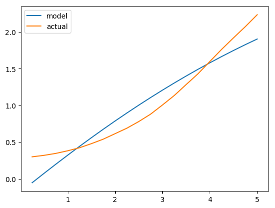

```python
plt.plot(term, ED_Curves.loc['2013-01-07'], label= 'model')
plt.plot(term, Training_Sample.loc['2013-01-07'], label = 'actual')
plt.legend()
plt.show()
```

## 2. Outer loop:

```python
def mini(p):

    error = (statevec(p)[0] - Training_Sample).mean()**2
    rmse = np.mean(error)
    print(p,rmse)
    return rmse
```

```python
#res = minimize(mini, p)
```

```
[ 0.1   0.1   0.11  0.08] 0.016494281442124323
[ 0.10000001  0.1         0.11        0.08      ] 0.016494278889294542
[ 0.1         0.10000001  0.11        0.08      ] 0.01649428396967928
[ 0.1         0.1         0.11000001  0.08      ] 0.016494281435736845
[ 0.1         0.1         0.11        0.08000001] 0.01649428532997797
[ 0.1   0.1   0.11  0.08] 0.016494281442124323
[ 0.27131751 -0.06962134  0.11042866 -0.18090944] 0.2099765735409731
[ 0.27131751 -0.06962134  0.11042866 -0.18090944] 0.2099765735409731
[ 0.27131752 -0.06962134  0.11042866 -0.18090944] 0.20997658237747846
[ 0.27131751 -0.06962133  0.11042866 -0.18090944] 0.20997669527062662
[ 0.27131751 -0.06962134  0.11042867 -0.18090944] 0.20997656229385261
[ 0.27131751 -0.06962134  0.11042866 -0.18090943] 0.20997657299299788
[ 0.1053407   0.09471218  0.11001336  0.07186634] 0.012926137789755968
[ 0.1053407   0.09471218  0.11001336  0.07186634] 0.012926137789755968
[ 0.10534071  0.09471218  0.11001336  0.07186634] 0.012926135540095595
[ 0.1053407   0.0947122   0.11001336  0.07186634] 0.012926140123673584
[ 0.1053407   0.09471218  0.11001338  0.07186634] 0.012926137991478187
[ 0.1053407   0.09471218  0.11001336  0.07186636] 0.012926140684203124
[ 0.12565218  0.06822334  0.09764916  0.07276755] 0.011455550713176343
[ 0.12565218  0.06822334  0.09764916  0.07276755] 0.011455550713176343
[ 0.1256522   0.06822334  0.09764916  0.07276755] 0.011455550682274903
[ 0.12565218  0.06822336  0.09764916  0.07276755] 0.011455556749529864
[ 0.12565218  0.06822334  0.09764917  0.07276755] 0.01145554946413156
[ 0.12565218  0.06822334  0.09764916  0.07276756] 0.011455549258360594
[ 0.20689813 -0.03773202  0.04819232  0.07637238] 0.02598668321172822
[ 0.20689813 -0.03773202  0.04819232  0.07637238] 0.02598668321172822
[ 0.20689815 -0.03773202  0.04819232  0.07637238] 0.02598668365484616
[ 0.20689813 -0.037732    0.04819232  0.07637238] 0.025986707587578033
[ 0.20689813 -0.03773202  0.04819234  0.07637238] 0.02598667567415091
[ 0.20689813 -0.03773202  0.04819232  0.07637239] 0.025986696622487676
[ 0.13233728  0.05950509  0.09357973  0.07306416] 0.009185194230121527
[ 0.13233728  0.05950509  0.09357973  0.07306416] 0.009185194230121527
[ 0.1323373   0.05950509  0.09357973  0.07306416] 0.00918519413244637
[ 0.13233728  0.05950511  0.09357973  0.07306416] 0.009185197567625524
[ 0.13233728  0.05950509  0.09357975  0.07306416] 0.009185193214705083
[ 0.13233728  0.05950509  0.09357973  0.07306418] 0.009185194688820857
[ 0.14908228  0.02360628  0.08620788  0.07602646] 0.0056555289827231285
[ 0.14908228  0.02360628  0.08620788  0.07602646] 0.0056555289827231285
[ 0.14908229  0.02360628  0.08620788  0.07602646] 0.005655528924116264
[ 0.14908228  0.0236063   0.08620788  0.07602646] 0.005655528491219726
```

[output cut: 1084 more lines]

```
[ 0.368013    0.01690212  0.2976569   0.1894652 ] 2.869310641469597e-05
[ 0.368013    0.01690212  0.2976569   0.1894652 ] 2.869310641469597e-05
[ 0.36801301  0.01690212  0.2976569   0.1894652 ] 2.8693106545285162e-05
[ 0.368013    0.01690214  0.2976569   0.1894652 ] 2.8693093311019347e-05
[ 0.368013    0.01690212  0.29765691  0.1894652 ] 2.869310247431763e-05
[ 0.368013    0.01690212  0.2976569   0.18946522] 2.869311485371452e-05
[ 0.36801236  0.01690294  0.29765727  0.18946364] 2.869185339632821e-05
[ 0.36801236  0.01690294  0.29765727  0.18946364] 2.869185339632821e-05
[ 0.36801238  0.01690294  0.29765727  0.18946364] 2.8691853589699127e-05
[ 0.36801236  0.01690295  0.29765727  0.18946364] 2.869184326610932e-05
[ 0.36801236  0.01690294  0.29765729  0.18946364] 2.8691852408457265e-05
[ 0.36801236  0.01690294  0.29765727  0.18946366] 2.8691855341849805e-05
[ 0.36801164  0.01690386  0.29765768  0.18946193] 2.8691459891203844e-05
[ 0.36801164  0.01690386  0.29765768  0.18946193] 2.8691459891203844e-05
[ 0.36801165  0.01690386  0.29765768  0.18946193] 2.8691459982155904e-05
```

[output not shown]

[output cut: 77 more lines]

[output not shown]

### Outer-Inner loop optimization:

As we can see from the results printed above the p vector and mean sqaured error doesnot chanage and it was taking too long for optimization program to run so I interrupt it and carryout the following analysis based on the last printed p vector above. This is due to limitation of my programming skills. Given more time I may work on to improve code to run it faster. But results are good enough to proceed with further analysis

```python
p_opt =np.array([ 0.36801165,  0.01690386,  0.29765768,  0.18946193])
```

```python
ED_Curves_opt, State_vectors_opt = statevec(p_opt)
display(ED_Curves_opt.head())
display(State_vectors_opt.head())
```

| Date | 0.25 | 0.5 | 0.75 | 1.0 | 1.25 | 1.5 | 1.75 | 2.0 | 2.25 | 2.5 | 2.75 | 3.0 | 3.25 | 3.5 | 3.75 | 4.0 | 4.25 | 4.5 | 4.75 | 5.0 |
| --- | --- | --- | --- | --- | --- | --- | --- | --- | --- | --- | --- | --- | --- | --- | --- | --- | --- | --- | --- | --- |
| 2011-01-03 | 0.571508 | 0.646496 | 0.755993 | 0.895505 | 1.061257 | 1.249922 | 1.458440 | 1.683889 | 1.923403 | 2.174116 | 2.433142 | 2.697563 | 2.964444 | 3.230848 | 3.493869 | 3.750669 | 3.998511 | 4.234804 | 4.457135 | 4.663310 |
| 2011-01-04 | 0.591880 | 0.664972 | 0.772600 | 0.910214 | 1.073991 | 1.260569 | 1.466856 | 1.689906 | 1.926833 | 2.174761 | 2.430795 | 2.692018 | 2.955497 | 3.218308 | 3.477560 | 3.730433 | 3.974216 | 4.206344 | 4.424437 | 4.626332 |
| 2011-01-05 | 0.724334 | 0.798782 | 0.908580 | 1.049049 | 1.216258 | 1.406744 | 1.617329 | 1.844981 | 2.086739 | 2.339649 | 2.600746 | 2.867042 | 3.135539 | 3.403248 | 3.667220 | 3.924578 | 4.172563 | 4.408564 | 4.630162 | 4.835159 |
| 2011-01-06 | 0.716420 | 0.787661 | 0.894059 | 1.030893 | 1.194194 | 1.380474 | 1.586533 | 1.809331 | 2.045899 | 2.293290 | 2.548549 | 2.808708 | 3.070795 | 3.331855 | 3.588976 | 3.839331 | 4.080206 | 4.309046 | 4.523488 | 4.721390 |
| 2011-01-07 | 0.619514 | 0.689884 | 0.794821 | 0.929697 | 1.090628 | 1.274198 | 1.477272 | 1.696871 | 1.930085 | 2.174020 | 2.425774 | 2.682429 | 2.941061 | 3.198759 | 3.452656 | 3.699961 | 3.937997 | 4.164240 | 4.376351 | 4.572215 |

| Date | x1 | x2 |
| --- | --- | --- |
| 2011-01-03 | -8.101020 | -25.288300 |
| 2011-01-04 | -8.115156 | -25.253719 |
| 2011-01-05 | -8.096639 | -25.155679 |
| 2011-01-06 | -8.122268 | -25.133725 |
| 2011-01-07 | -8.135340 | -25.205803 |

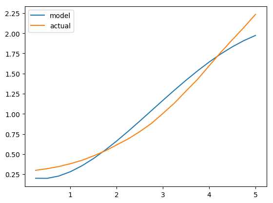

```python
plt.plot(term, ED_Curves_opt.loc['2013-01-07'], label= 'model')
plt.plot(term, Training_Sample.loc['2013-01-07'], label = 'actual')
plt.legend()
plt.show()
```

## In-sample time series properties of the residuals:

```python
Residuals = Training_Sample - ED_Curves_opt
Residuals.head()
```

| Date | 0.25 | 0.5 | 0.75 | 1.0 | 1.25 | 1.5 | 1.75 | 2.0 | 2.25 | 2.5 | 2.75 | 3.0 | 3.25 | 3.5 | 3.75 | 4.0 | 4.25 | 4.5 | 4.75 | 5.0 |
| --- | --- | --- | --- | --- | --- | --- | --- | --- | --- | --- | --- | --- | --- | --- | --- | --- | --- | --- | --- | --- |
| 2011-01-03 | -0.191580 | -0.190761 | -0.186529 | -0.147923 | -0.091968 | -0.011558 | 0.057351 | 0.118576 | 0.156056 | 0.192034 | 0.199852 | 0.202437 | 0.163075 | 0.124179 | 0.078883 | 0.035538 | -0.032834 | -0.105261 | -0.178204 | -0.245446 |
| 2011-01-04 | -0.206345 | -0.185101 | -0.165207 | -0.114647 | -0.051846 | 0.024808 | 0.075457 | 0.114415 | 0.134990 | 0.159156 | 0.165102 | 0.165692 | 0.129503 | 0.099147 | 0.062496 | 0.027836 | -0.031989 | -0.090664 | -0.149472 | -0.207062 |
| 2011-01-05 | -0.323262 | -0.265080 | -0.209657 | -0.121918 | -0.028447 | 0.068494 | 0.134061 | 0.177454 | 0.192886 | 0.206887 | 0.197731 | 0.183214 | 0.136925 | 0.096752 | 0.055300 | 0.015945 | -0.048395 | -0.111015 | -0.173520 | -0.234352 |
| 2011-01-06 | -0.289753 | -0.241179 | -0.200304 | -0.122174 | -0.028327 | 0.072727 | 0.137151 | 0.175247 | 0.185853 | 0.190178 | 0.172351 | 0.159018 | 0.114076 | 0.080667 | 0.046024 | 0.013434 | -0.044094 | -0.099631 | -0.155171 | -0.209048 |
| 2011-01-07 | -0.191603 | -0.168976 | -0.159073 | -0.112599 | -0.045097 | 0.035296 | 0.093841 | 0.130015 | 0.139241 | 0.147352 | 0.138162 | 0.133073 | 0.096419 | 0.071391 | 0.044878 | 0.020039 | -0.029997 | -0.078070 | -0.126525 | -0.173558 |

```python
Volatility = Residuals.std()
display(Volatility)
```

```
0.25    0.231300
0.50    0.220031
0.75    0.183510
1.00    0.128277
1.25    0.069922
1.50    0.066718
1.75    0.112764
2.00    0.153538
2.25    0.182607
2.50    0.198135
2.75    0.197630
3.00    0.180601
3.25    0.151726
3.50    0.113949
3.75    0.071296
4.00    0.041017
4.25    0.056876
4.50    0.112280
4.75    0.174573
5.00    0.239704
dtype: float64
```

```python
def adf_test(df):
    adf = adfuller(df)
    y = 'Time Series is stationary'
    n = 'Time series is not stationary'
    if adf[0]<=adf[4]['5%']:
        return [adf[0],adf[4]['5%'],adf[1],y]
    else:
        return [adf[0],adf[4]['5%'],adf[1],n]
```

```python
Statinarity_Residuals = pd.DataFrame([adf_test(Residuals[i]) for i in Residuals.columns])
header = ['ADF Statistics', 't at 95% CD','p-value','Result']
Statinarity_Residuals.columns = header
Statinarity_Residuals.index = Testing_Sample.columns
Statinarity_Residuals
```

|  | ADF Statistics | t at 95% CD | p-value | Result |
| --- | --- | --- | --- | --- |
| 0.25 | -0.743866 | -2.864500 | 0.835058 | Time series is not stationary |
| 0.50 | -0.823413 | -2.864509 | 0.812148 | Time series is not stationary |
| 0.75 | -1.194233 | -2.864509 | 0.676072 | Time series is not stationary |
| 1.00 | -1.555117 | -2.864509 | 0.506091 | Time series is not stationary |
| 1.25 | -1.685579 | -2.864491 | 0.438557 | Time series is not stationary |
| 1.50 | -1.234823 | -2.864470 | 0.658439 | Time series is not stationary |
| 1.75 | -0.754037 | -2.864503 | 0.832252 | Time series is not stationary |
| 2.00 | -0.734008 | -2.864509 | 0.837743 | Time series is not stationary |
| 2.25 | -0.862504 | -2.864509 | 0.800070 | Time series is not stationary |
| 2.50 | -0.967627 | -2.864509 | 0.764888 | Time series is not stationary |
| 2.75 | -1.107732 | -2.864509 | 0.711979 | Time series is not stationary |
| 3.00 | -1.193168 | -2.864509 | 0.676528 | Time series is not stationary |
| 3.25 | -1.280320 | -2.864509 | 0.638127 | Time series is not stationary |
| 3.50 | -1.558369 | -2.864491 | 0.504465 | Time series is not stationary |
| 3.75 | -1.693765 | -2.864491 | 0.434328 | Time series is not stationary |
| 4.00 | -2.036844 | -2.864491 | 0.270656 | Time series is not stationary |
| 4.25 | -0.672277 | -2.864512 | 0.853800 | Time series is not stationary |
| 4.50 | -0.798081 | -2.864521 | 0.819685 | Time series is not stationary |
| 4.75 | -1.120779 | -2.864521 | 0.706715 | Time series is not stationary |
| 5.00 | -1.023788 | -2.864494 | 0.744490 | Time series is not stationary |

```python
def half_life(df):
    mu = df.mean()
    df_t = df[:-1] - mu
    df_lag = df[1:] - mu
    a = np.matrix(df_t) * np.matrix(df_lag).T
    b = np.matrix(df_t) * np.matrix(df_t).T
    l = -math.log(a/b)
    h = math.log(2)/l
    return h
```

```python
Halflife_Residuals = pd.DataFrame([half_life(Residuals[i]) for i in Residuals.columns])
Halflife_Residuals.index = Training_Sample.columns
Halflife_Residuals.columns = ['Half Life']
Halflife_Residuals
```

|  | Half Life |
| --- | --- |
| 0.25 | 51.901163 |
| 0.50 | 58.471577 |
| 0.75 | 54.350354 |
| 1.00 | 35.106056 |
| 1.25 | 29.184536 |
| 1.50 | 18.272371 |
| 1.75 | 59.427287 |
| 2.00 | 51.014427 |
| 2.25 | 51.458292 |
| 2.50 | 48.160002 |
| 2.75 | 45.603237 |
| 3.00 | 44.728058 |
| 3.25 | 27.036366 |
| 3.50 | 72.709464 |
| 3.75 | 39.261859 |
| 4.00 | 1.588691 |
| 4.25 | 50.975078 |
| 4.50 | 75.628877 |
| 4.75 | 25.322618 |
| 5.00 | 9.240663 |

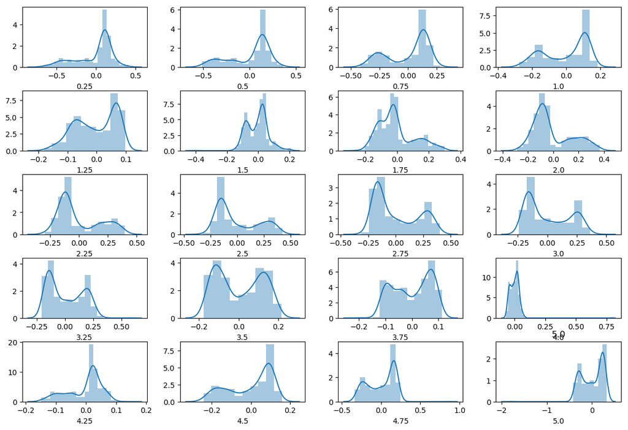

```python
fig2, ax = plt.subplots(nrows=5, ncols=4,figsize=(12,8))
num=0
title =list(Residuals.columns)
plt.tight_layout()
for row in range(5):
    for col in range(4):
        sns.distplot(Residuals[Residuals.columns[num]], ax=ax[row, col])
        plt.title(title[num])
        num+=1
        if num == 20:
            break
plt.show()
```

## Result Analysis:

All the 2y,3y,4y,5y futures are non-stationary, disitributions fo each of them are bimodal while 4 year is positively skewed on the hand 5 year is neagtively skewed. 2 and 3 yr have halflife of 40 to 50 days while half life of 4 and 5 yrs are 1.6 and 9.2 resp.

## 3. Collinearity Detection:

### To detect collinearity I follow the simple approch that I found on Stack overflow and its results are good. I basically find out the correlation matrix of the predicted data and find the eigen value decomposition of that data and calculate condition number.

https://stackoverflow.com/questions/25676145/capturing-high-multi-collinearity-in-statsmodels

```python
corelation_mat = np.corrcoef(ED_Curves_opt, rowvar = 0)
eig, vec = np.linalg.eig(corelation_mat)
condition_number = abs(eig[0]/eig[-1])
condition_number
```

```
2.7845956187755862e+17
```

### Condition number:

As we can see the condition number is astronomically high. So there is collinearity.

## Residual Export:

```python
def statevec_outsample(p, df):
    state_vector = []
    ED_curv = []
    for date in (df.index):
        def func(t,x1,x2):
            return ED_futures(t, p, c, x1,x2)
        x, cov = curve_fit(func, xdata = df.columns.values, ydata = df.loc[date].values )
        state_vector.append(x)
        x1 = x[0]
        x2 = x[1]
        ft_curve = []
        for ter in (df.columns):
            ft_curve.append(ED_futures(ter, p, c, x1, x2))
        ED_curv.append(ft_curve)
    State_vectors  =  pd.DataFrame(state_vector)
    State_vectors.columns = ['x1', 'x2']
    State_vectors.index = df.index

    ED_Curves = pd.DataFrame(ED_curv)
    ED_Curves.columns = df.columns
    ED_Curves.index = df.index

    return ED_Curves, State_vectors
```

```python
Cross_Val_Sample_model = statevec_outsample(p_opt,Cross_Val_Sample)
Residuals_crossval = Cross_Val_Sample - Cross_Val_Sample_model[0]
```

```python
Testing_Sample_model = statevec_outsample(p_opt,Testing_Sample)
Residuals_testing = Testing_Sample - Testing_Sample_model[0]
```

```python
Residuals_out = pd.concat([Residuals,Residuals_crossval, Residuals_testing])
```

```python
Residuals_out.to_csv('Residuals.csv')
```